# STAT 420: Homework 08

Jeffery Haag

11/01/20 AD

## Exercise 1 (EPA Emissions Data)

**(a)**

```r
epa = read.csv("epa2015.csv")
str(epa)
```

```
## 'data.frame':    4411 obs. of  16 variables:
##  $ Make     : chr  "aston martin" "aston martin" "aston martin" "aston martin" ...
##  $ Model    : chr  "DB9" "DB9" "Rapide S" "Rapide S" ...
##  $ ID       : chr  "143TT1042" "143TT1042" "410TT4202" "410TT4202" ...
##  $ disp     : num  5.9 5.9 6 6 6 6 4.7 4.7 4.7 4.7 ...
##  $ type     : chr  "Car" "Car" "Car" "Car" ...
##  $ horse    : int  510 510 552 552 565 565 420 420 430 430 ...
##  $ cyl      : int  12 12 12 12 12 12 8 8 8 8 ...
##  $ lockup   : chr  "Y" "Y" "Y" "Y" ...
##  $ drive    : chr  "R" "R" "R" "R" ...
##  $ weight   : int  4500 4500 4750 4750 4250 4250 4000 4000 4000 4000 ...
##  $ axleratio: num  3.46 3.46 2.73 2.73 3.73 3.73 3.91 3.91 4.18 4.18 ...
##  $ nvratio  : num  31 31 22.4 22.4 33.6 33.6 38.6 38.6 36.2 36.2 ...
##  $ THC      : num  0.0251 0.0022 0.0269 0.0008 0.0248 ...
##  $ CO       : num  0.12 0.0118 0.5 0.06 0.61 ...
##  $ CO2      : num  550 344 512 297 603 ...
##  $ mpg      : num  16.1 25.8 17.3 29.9 14.8 25.3 16 26.5 16.7 28.8 ...
```

```r
epa$type = as.factor(epa$type)
str(epa)
```

```
## 'data.frame':    4411 obs. of  16 variables:
##  $ Make     : chr  "aston martin" "aston martin" "aston martin" "aston martin" ...
##  $ Model    : chr  "DB9" "DB9" "Rapide S" "Rapide S" ...
##  $ ID       : chr  "143TT1042" "143TT1042" "410TT4202" "410TT4202" ...
##  $ disp     : num  5.9 5.9 6 6 6 6 4.7 4.7 4.7 4.7 ...
##  $ type     : Factor w/ 3 levels "Both","Car","Truck": 2 2 2 2 2 2 2 2 2 2 ...
##  $ horse    : int  510 510 552 552 565 565 420 420 430 430 ...
##  $ cyl      : int  12 12 12 12 12 12 8 8 8 8 ...
##  $ lockup   : chr  "Y" "Y" "Y" "Y" ...
##  $ drive    : chr  "R" "R" "R" "R" ...
##  $ weight   : int  4500 4500 4750 4750 4250 4250 4000 4000 4000 4000 ...
##  $ axleratio: num  3.46 3.46 2.73 2.73 3.73 3.73 3.91 3.91 4.18 4.18 ...
##  $ nvratio  : num  31 31 22.4 22.4 33.6 33.6 38.6 38.6 36.2 36.2 ...
##  $ THC      : num  0.0251 0.0022 0.0269 0.0008 0.0248 ...
##  $ CO       : num  0.12 0.0118 0.5 0.06 0.61 ...
##  $ CO2      : num  550 344 512 297 603 ...
##  $ mpg      : num  16.1 25.8 17.3 29.9 14.8 25.3 16 26.5 16.7 28.8 ...
```

**(b)**

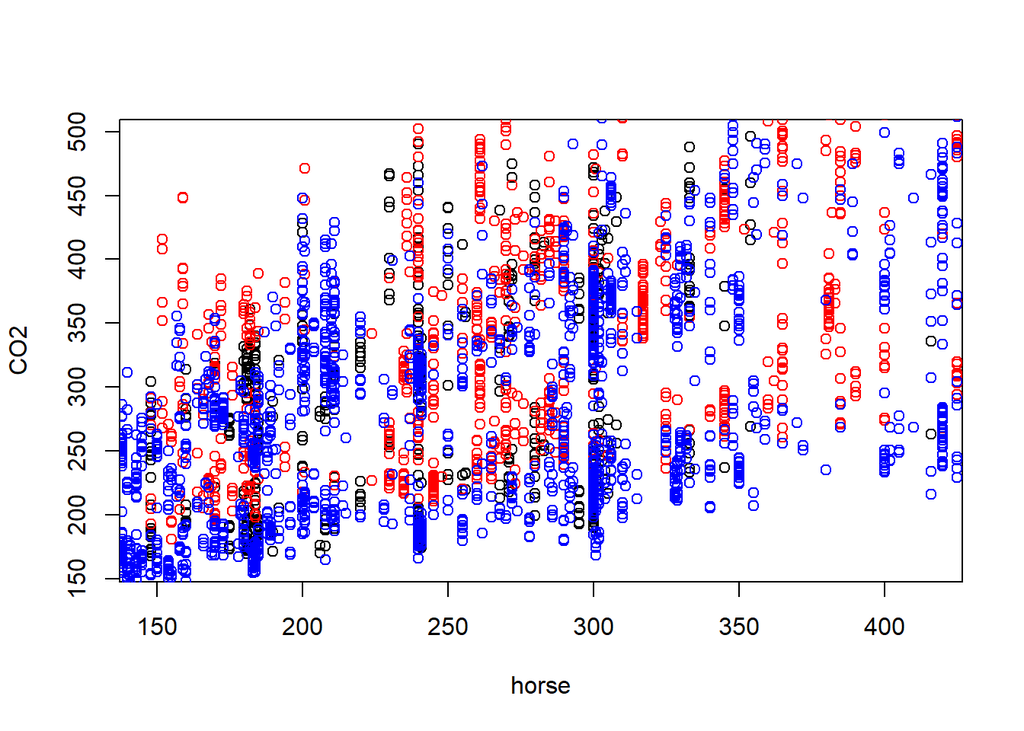

```r
plot(CO2 ~ horse, data = subset(epa,type=="Both"), col ="black")
points(CO2 ~ horse, data = subset(epa,type=="Truck"), col ="red")
points(CO2 ~ horse, data = subset(epa,type=="Car"), col = "blue")
```

**(c)**

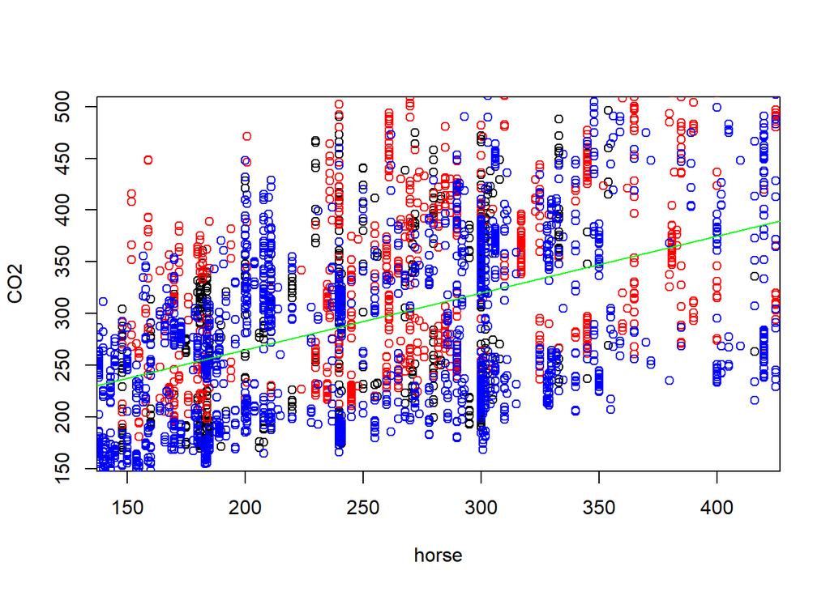

```r
hoModel = lm(CO2 ~ horse, data=epa)
plot(CO2 ~ horse, data = subset(epa,type=="Both"), col ="black")
points(CO2 ~ horse, data = subset(epa,type=="Truck"), col ="red")
points(CO2 ~ horse, data = subset(epa,type=="Car"), col = "blue")
abline(hoModel, col = "green")
```

```r
coef(hoModel)["horse"]
```

```
##     horse
## 0.5498996
```

```r
predict(hoModel, data.frame(horse=148), interval="confidence")
```

```
##       fit      lwr      upr
## 1 236.103 232.2978 239.9082
```

It models the data not so well, but the data doesn’t look like it can be modeled well because there’s just too much noise. It seems to mostly be following the car and not really the others as well. The estimate is 0.5499 cO2/horsepower on average.

The lower bound is 232.2978 and upper bound is 239.9082 co2 for the prediction on the Subaru Impreza Wagon.

**(d)**

```r
co2Ad = lm(CO2~horse+type,data=epa)
coef(co2Ad)
```

```
## (Intercept)       horse     typeCar   typeTruck
## 155.9821483   0.5611008 -22.4250731  40.0744433
```

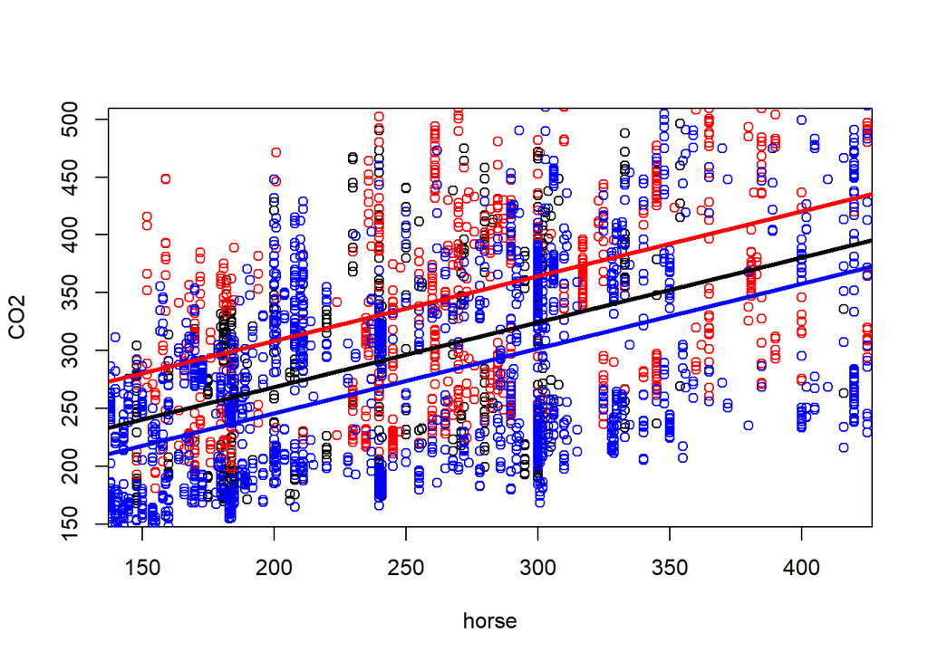

```r
addBoth = coef(co2Ad)[1]
addCar = coef(co2Ad)[1] + coef(co2Ad)[3]
addTruck = coef(co2Ad)[1] + coef(co2Ad)[4]
avgSlope = coef(co2Ad)[2]


plot(CO2 ~ horse, data = subset(epa,type=="Both"), col ="black")
points(CO2 ~ horse, data = subset(epa,type=="Truck"), col ="red")
points(CO2 ~ horse, data = subset(epa,type=="Car"), col = "blue")

abline(addBoth, avgSlope, col ="black", lwd = 3)
abline(addCar, avgSlope, col = "blue", lwd = 3)
abline(addTruck, avgSlope, col ="red",lwd = 3)
```

```r
predict(co2Ad, data.frame(horse=148,type="Both"), interval="confidence")
```

```
##        fit      lwr      upr
## 1 239.0251 232.1156 245.9345
```

The lines are better like this because before it seemed to be skewed towards blue/car but now the trucks have a more accurate line.

**(e)**

```r
co2Int = lm(CO2~horse*type,data=epa)
coef(co2Int)
```

```
##     (Intercept)           horse         typeCar       typeTruck   horse:typeCar
##    149.89711799      0.58605967    -11.17957646      7.66403763     -0.04285633
## horse:typeTruck
##      0.11532862
```

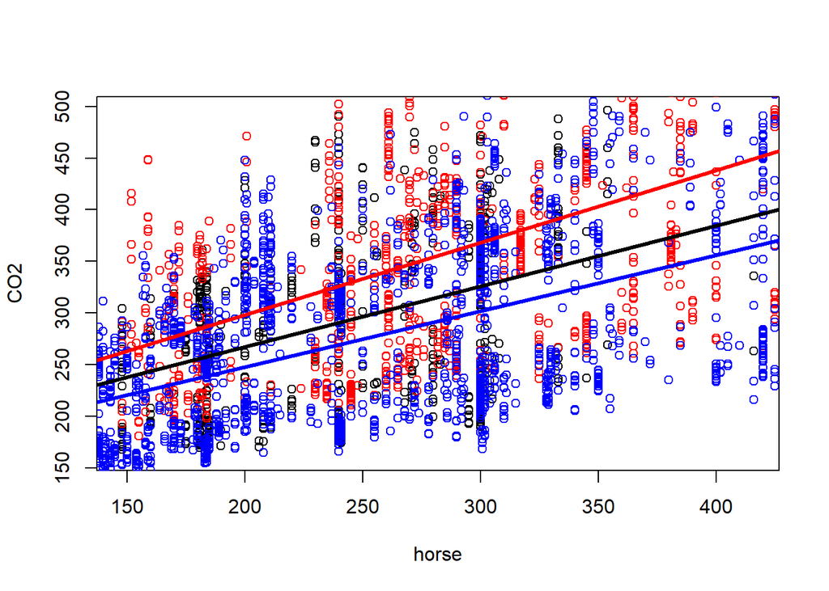

```r
intBoth = coef(co2Int)[1]
intCar = coef(co2Int)[1] + coef(co2Int)[3]
intTruck = coef(co2Int)[1] + coef(co2Int)[4]

bothSl = coef(co2Int)[2]
carSl = coef(co2Int)[2] + coef(co2Int)[5]
truckSlo = coef(co2Int)[2] + coef(co2Int)[6]


plot(CO2 ~ horse, data = subset(epa,type=="Both"), col ="black")
points(CO2 ~ horse, data = subset(epa,type=="Truck"), col ="red")
points(CO2 ~ horse, data = subset(epa,type=="Car"), col = "blue")

abline(intBoth, bothSl, col ="black", lwd = 3)
abline(intCar, carSl, col = "blue", lwd = 3)
abline(intTruck, truckSlo, col ="red",lwd = 3)
```

```r
predict(co2Int, data.frame(horse=148,type="Both"), interval="confidence")
```

```
##        fit      lwr      upr
## 1 236.6339 223.4375 249.8304
```

The lines are better like this, red seems to be way better off and blue a bit better as well.

**(f)** I personally think the third one is the best(the interaction model). It still isn’t that great, but its the best of the three.

**(g)**

```r
anova(hoModel, co2Ad)
```

```
## Analysis of Variance Table
##
## Model 1: CO2 ~ horse
## Model 2: CO2 ~ horse + type
##   Res.Df      RSS Df Sum of Sq      F    Pr(>F)
## 1   4409 35012540
## 2   4407 32054899  2   2957641 203.31 < 2.2e-16 ***
## ---
## Signif. codes:  0 '***' 0.001 '**' 0.01 '*' 0.05 '.' 0.1 ' ' 1
```

At alpha=0.01 this passes the p test so the additive is going to be the better model.

**(h)**

```r
anova(hoModel, co2Int)
```

```
## Analysis of Variance Table
##
## Model 1: CO2 ~ horse
## Model 2: CO2 ~ horse * type
##   Res.Df      RSS Df Sum of Sq      F    Pr(>F)
## 1   4409 35012540
## 2   4405 31894278  4   3118262 107.67 < 2.2e-16 ***
## ---
## Signif. codes:  0 '***' 0.001 '**' 0.01 '*' 0.05 '.' 0.1 ' ' 1
```

At alpha =0.01 it passes the p test so the interactive model is going to be the best one like I predicted, Booyakasha

## Exercise 2 (Hospital SUPPORT Data)

**(a)**

```r
hos = read.csv("hospital.csv")
str(hos)
```

```
## 'data.frame':    580 obs. of  13 variables:
##  $ Days       : int  8 14 21 4 11 9 25 26 9 16 ...
##  $ Age        : num  42.3 63.7 41.5 42 52.1 ...
##  $ Sex        : chr  "female" "female" "male" "male" ...
##  $ Comorbidity: chr  "no" "no" "yes" "yes" ...
##  $ EdYears    : int  11 22 18 16 8 12 12 13 16 30 ...
##  $ Education  : chr  "low" "high" "high" "high" ...
##  $ Income     : chr  "high" "high" "high" "high" ...
##  $ Charges    : num  9914 283303 320843 4173 13414 ...
##  $ Care       : chr  "low" "high" "high" "low" ...
##  $ Race       : chr  "non-white" "white" "white" "white" ...
##  $ Pressure   : int  84 69 66 97 89 57 99 115 93 102 ...
##  $ Blood      : num  11.3 30.1 0.2 10.8 6.4 ...
##  $ Rate       : int  94 108 130 88 92 114 150 132 86 90 ...
```

```r
hos$Care = as.factor(hos$Care)
hos$Race = as.factor(hos$Race)
str(hos)
```

```
## 'data.frame':    580 obs. of  13 variables:
##  $ Days       : int  8 14 21 4 11 9 25 26 9 16 ...
##  $ Age        : num  42.3 63.7 41.5 42 52.1 ...
##  $ Sex        : chr  "female" "female" "male" "male" ...
##  $ Comorbidity: chr  "no" "no" "yes" "yes" ...
##  $ EdYears    : int  11 22 18 16 8 12 12 13 16 30 ...
##  $ Education  : chr  "low" "high" "high" "high" ...
##  $ Income     : chr  "high" "high" "high" "high" ...
##  $ Charges    : num  9914 283303 320843 4173 13414 ...
##  $ Care       : Factor w/ 2 levels "high","low": 2 1 1 2 2 2 2 1 2 2 ...
##  $ Race       : Factor w/ 2 levels "non-white","white": 1 2 2 2 2 2 2 2 2 2 ...
##  $ Pressure   : int  84 69 66 97 89 57 99 115 93 102 ...
##  $ Blood      : num  11.3 30.1 0.2 10.8 6.4 ...
##  $ Rate       : int  94 108 130 88 92 114 150 132 86 90 ...
```

**(b)**

```r
hoAdd = lm(Days~Charges+Pressure+Care+Race,data=hos)
summary(hoAdd)
```

```
##
## Call:
## lm(formula = Days ~ Charges + Pressure + Care + Race, data = hos)
##
## Residuals:
##     Min      1Q  Median      3Q     Max
## -79.792  -5.003  -1.463   3.098 133.017
##
## Coefficients:
##               Estimate Std. Error t value Pr(>|t|)
## (Intercept) -3.850e+00  2.936e+00  -1.311   0.1903
## Charges      1.909e-04  9.580e-06  19.926  < 2e-16 ***
## Pressure     1.032e-01  2.625e-02   3.931 9.48e-05 ***
## Carelow     -9.646e-02  1.545e+00  -0.062   0.9502
## Racewhite    3.069e+00  1.652e+00   1.858   0.0637 .
## ---
## Signif. codes:  0 '***' 0.001 '**' 0.01 '*' 0.05 '.' 0.1 ' ' 1
##
## Residual standard error: 16.45 on 575 degrees of freedom
## Multiple R-squared:  0.4749, Adjusted R-squared:  0.4713
## F-statistic:   130 on 4 and 575 DF,  p-value: < 2.2e-16
```

**(c)**

```r
hoC = lm(Days~Charges+Pressure+Care+Race+Care*Charges+Care*Pressure,data=hos)
anova(hoAdd,hoC)
```

```
## Analysis of Variance Table
##
## Model 1: Days ~ Charges + Pressure + Care + Race
## Model 2: Days ~ Charges + Pressure + Care + Race + Care * Charges + Care *
##     Pressure
##   Res.Df    RSS Df Sum of Sq      F   Pr(>F)
## 1    575 155596
## 2    573 152996  2    2600.2 4.8692 0.008001 **
## ---
## Signif. codes:  0 '***' 0.001 '**' 0.01 '*' 0.05 '.' 0.1 ' ' 1
```

At alpha =0.01 we can reject the null and the new model is going to bet better I think.

**(d)**

```r
hoD = lm(Days~Charges+Pressure+Care+Race+Care*Charges+Care*Pressure+ Race*Charges+Race*Pressure,data=hos)
anova(hoC,hoD)
```

```
## Analysis of Variance Table
##
## Model 1: Days ~ Charges + Pressure + Care + Race + Care * Charges + Care *
##     Pressure
## Model 2: Days ~ Charges + Pressure + Care + Race + Care * Charges + Care *
##     Pressure + Race * Charges + Race * Pressure
##   Res.Df    RSS Df Sum of Sq      F    Pr(>F)
## 1    573 152996
## 2    571 147730  2    5266.4 10.178 4.538e-05 ***
## ---
## Signif. codes:  0 '***' 0.001 '**' 0.01 '*' 0.05 '.' 0.1 ' ' 1
```

At alpha =0.01 we can reject the null and the new model is going to bet better I think. That is with race being interactive.

**(e)**

```r
coef(hoD)["Pressure"]+coef(hoD)["Pressure:Racewhite"]
```

```
##  Pressure
## 0.1423975
```

We predict 0.1424 increase for a 1 unit increase.

**(f)**

```r
hoF = lm(Days~Charges+Care+Race+Care*Charges+Race*Charges,data=hos)
anova(hoD,hoF)
```

```
## Analysis of Variance Table
##
## Model 1: Days ~ Charges + Pressure + Care + Race + Care * Charges + Care *
##     Pressure + Race * Charges + Race * Pressure
## Model 2: Days ~ Charges + Care + Race + Care * Charges + Race * Charges
##   Res.Df    RSS Df Sum of Sq      F    Pr(>F)
## 1    571 147730
## 2    574 153208 -3   -5478.6 7.0586 0.0001152 ***
## ---
## Signif. codes:  0 '***' 0.001 '**' 0.01 '*' 0.05 '.' 0.1 ' ' 1
```

## Exercise 3 (Fish Data)

**(a)**

```r
fishies = read.csv("fish.csv")
fish1 = lm(Weight ~ Length1*HeightPct*WidthPct,data=fishies)
```

**(b)**

```r
fish_smaller = lm(Weight ~ Length1 + HeightPct * WidthPct, data = fishies)
anova(fish1, fish_smaller)
```

```
## Analysis of Variance Table
##
## Model 1: Weight ~ Length1 * HeightPct * WidthPct
## Model 2: Weight ~ Length1 + HeightPct * WidthPct
##   Res.Df     RSS Df Sum of Sq      F    Pr(>F)
## 1    150 1868778
## 2    153 2480494 -3   -611716 16.367 2.972e-09 ***
## ---
## Signif. codes:  0 '***' 0.001 '**' 0.01 '*' 0.05 '.' 0.1 ' ' 1
```

**(c)**

```r
coef(fish1)
```

```
##                (Intercept)                    Length1
##              -2070.0789433                101.8805290
##                  HeightPct                   WidthPct
##                 99.6568303                137.1369880
##          Length1:HeightPct           Length1:WidthPct
##                 -4.2017983                 -6.3483423
##         HeightPct:WidthPct Length1:HeightPct:WidthPct
##                 -7.9976087                  0.3512455
```

```r
ansc = 101.8805390 + -4.2017983 *20 +  -6.3483423*10 +0.3512455 *20*10
ansc
```

```
## [1] 24.61025
```

**(d)**

```r
coef(fish_smaller)
```

```
##        (Intercept)            Length1          HeightPct           WidthPct
##         277.647815          31.485216         -38.031377         -69.884076
## HeightPct:WidthPct
##           3.328871
```

```r
ansd = 31.485216
```

We expect 31.485 weight gain.

## Exercise 4 ($t$-test Is a Linear Model)

```r
n = 16

ex4 = data.frame(
  groups = c(rep("A", n / 2), rep("B", n / 2)),
  values = rep(0, n))
str(ex4)
```

```
## 'data.frame':    16 obs. of  2 variables:
##  $ groups: chr  "A" "A" "A" "A" ...
##  $ values: num  0 0 0 0 0 0 0 0 0 0 ...
```

```r
ex4$values = rnorm(n, mean = 10, sd = 3) # simualte data
summary(lm(values ~ groups, data = ex4))
```

```
##
## Call:
## lm(formula = values ~ groups, data = ex4)
##
## Residuals:
##     Min      1Q  Median      3Q     Max
## -7.1796 -1.7602  0.9002  2.0295  4.4866
##
## Coefficients:
##             Estimate Std. Error t value Pr(>|t|)
## (Intercept)  10.1425     1.2082   8.395 7.79e-07 ***
## groupsB      -0.6046     1.7087  -0.354    0.729
## ---
## Signif. codes:  0 '***' 0.001 '**' 0.01 '*' 0.05 '.' 0.1 ' ' 1
##
## Residual standard error: 3.417 on 14 degrees of freedom
## Multiple R-squared:  0.008863,   Adjusted R-squared:  -0.06193
## F-statistic: 0.1252 on 1 and 14 DF,  p-value: 0.7287
```

```r
t.test(values ~ groups, data = ex4, var.equal = TRUE)
```

```
##
##  Two Sample t-test
##
## data:  values by groups
## t = 0.35383, df = 14, p-value = 0.7287
## alternative hypothesis: true difference in means is not equal to 0
## 95 percent confidence interval:
##  -3.060217  4.269385
## sample estimates:
## mean in group A mean in group B
##        10.14253         9.53795
```

```r
num_sims = 100
lm_t = rep(0, num_sims)
lm_p = rep(0, num_sims)
tt_t = rep(0, num_sims)
tt_p = rep(0, num_sims)
```

**(a)**

```r
UIN = 673856275
set.seed(UIN)
for (i in 1:100) {
  ex4$values = rnorm(n, mean = 10, sd = 3)
  lm_t[i] = summary(lm(formula = values ~ groups, data = ex4))$coefficients[2,3]
  lm_p[i] = summary(lm(formula = values ~ groups, data = ex4))$coefficients[2,4]
  tt_t[i] = t.test(values ~ groups, data = ex4, var.equal = TRUE)$stat
  tt_p[i] = t.test(values ~ groups, data = ex4, var.equal = TRUE)$p.val
}
```

**(b)**

```r
mean(lm_t == tt_t)
```

```
## [1] 0
```

**(c)**

```r
 mean(lm_p == tt_p)
```

```
## [1] 0.21
```

**(d)**

```r
all.equal(lm_p, tt_p)
```

```
## [1] TRUE
```

Theyre equal. They are equivalent theres just a slight computer issue with checking it. **(e)**

```r
lm_t
```

```
##   [1] -1.31086099 -5.20870378 -0.69104742  0.66630878  1.79943319  0.12006201
##   [7]  0.50093940 -2.75252600 -0.61005015  0.64210224 -1.48458877 -0.64057364
##  [13]  0.57248647 -0.07659730  0.44096867  0.13410032  0.56283778  0.63451086
##  [19]  2.65992230  0.97957058 -0.79417904  1.08263237  0.37242163  1.51734554
##  [25] -0.21197006  1.26716537  0.24975157 -2.03543474 -0.84187360 -0.66095024
##  [31] -0.37105976 -1.22361141 -0.14977920 -0.60375091 -0.18444061  0.95246326
##  [37] -0.36419671  0.15663106  0.29611071 -0.67282549  2.02761028  2.25108832
##  [43]  0.68008173  0.58903779  1.93354267  0.90617678 -0.99956018  0.78814938
##  [49]  1.18142725 -0.26373603 -0.94668208  0.24991949 -0.61427885  0.58426086
##  [55] -0.95592471  0.56932498  1.81663681  1.45033026  0.62657821  0.29464966
##  [61]  0.66375185  0.38924358  0.70459739  0.01408217  0.40796478 -0.07575985
##  [67]  0.47341623 -1.93777416  0.13409388 -1.27162507  0.92331694  0.85672214
##  [73] -0.42336367  0.47847825  0.95166479  2.10826358  0.23311547  0.16874450
##  [79]  0.30342081 -0.83835777 -1.36123245 -0.65248532 -0.62275198  1.21912748
##  [85]  0.62706086  1.63723958 -0.30586585 -0.64716132 -0.95795364 -0.14482291
##  [91] -1.57919983 -0.46786135 -1.10689570  1.22678304 -0.60578046  0.02558874
##  [97]  0.42973396 -0.76613630 -0.15996641 -0.77328955
```

```r
tt_t
```

```
##   [1]  1.31086099  5.20870378  0.69104742 -0.66630878 -1.79943319 -0.12006201
##   [7] -0.50093940  2.75252600  0.61005015 -0.64210224  1.48458877  0.64057364
##  [13] -0.57248647  0.07659730 -0.44096867 -0.13410032 -0.56283778 -0.63451086
##  [19] -2.65992230 -0.97957058  0.79417904 -1.08263237 -0.37242163 -1.51734554
##  [25]  0.21197006 -1.26716537 -0.24975157  2.03543474  0.84187360  0.66095024
##  [31]  0.37105976  1.22361141  0.14977920  0.60375091  0.18444061 -0.95246326
##  [37]  0.36419671 -0.15663106 -0.29611071  0.67282549 -2.02761028 -2.25108832
##  [43] -0.68008173 -0.58903779 -1.93354267 -0.90617678  0.99956018 -0.78814938
##  [49] -1.18142725  0.26373603  0.94668208 -0.24991949  0.61427885 -0.58426086
##  [55]  0.95592471 -0.56932498 -1.81663681 -1.45033026 -0.62657821 -0.29464966
##  [61] -0.66375185 -0.38924358 -0.70459739 -0.01408217 -0.40796478  0.07575985
##  [67] -0.47341623  1.93777416 -0.13409388  1.27162507 -0.92331694 -0.85672214
##  [73]  0.42336367 -0.47847825 -0.95166479 -2.10826358 -0.23311547 -0.16874450
##  [79] -0.30342081  0.83835777  1.36123245  0.65248532  0.62275198 -1.21912748
##  [85] -0.62706086 -1.63723958  0.30586585  0.64716132  0.95795364  0.14482291
##  [91]  1.57919983  0.46786135  1.10689570 -1.22678304  0.60578046 -0.02558874
##  [97] -0.42973396  0.76613630  0.15996641  0.77328955
```

The values in tt_t and lm_t are negatives of each other. Yes we calculate the two with the difference between means as a facotr and they are reversed for the two values so we get the negatives of each other.ex(a-b) vs (b-a).